# Ferrari Stock Time Series Forecasting Using ARIMA

Mark Zusman

November 8th 2025

## Introduction

This notebook performs a full time series analysis of Ferrari N.V. (ticker: RACE) using historical daily closing prices. The dataset was sourced from the Wall Street Journal and covers the period **April 17, 2023 through April 17, 2024**. The goal of this analysis is to evaluate the stationarity of the series, determine an appropriate ARIMA structure, and generate short-term forecasts of the stock’s behavior.

Dataset Link: https://www.wsj.com/market-data/quotes/RACE/historical-prices

The workflow includes:

- **KPSS Unit Root Testing** to assess stationarity of both the raw and differenced series
- **ACF and PACF visualization** to guide ARIMA order selection
- **ARIMA model fitting**, including manual models as well as `auto.arima()`
- **Residual diagnostics** using the Ljung-Box test and residual plots
- **Forecast generation** with confidence intervals using the final selected model

This notebook demonstrates a complete time series modeling pipeline—from data loading and transformation through forecasting—applied to one year of Ferrari stock price data.

```r
# Removing messages and warnings from final output

knitr::opts_chunk$set(echo = TRUE, message = FALSE, warning = FALSE)


# Time-series tests (KPSS), ARIMA modeling & diagnostics, plotting

library(urca)       # Unit-root and cointegration tests (KPSS)
library(forecast)   # ARIMA, forecast(), ggAcf/ggPacf, checkresiduals()
library(feasts)     # Additional time-series tools (ACF/PACF)
library(ggplot2)    # Plotting
```

```r
# attaching dataframe
attach(Ferrari_HistoricalPrices)
df = Ferrari_HistoricalPrices
```

## KPSS Unit Root Test

This test checks whether the original closing price series is stationary. A significant p-value means the data is NOT stationary, which is common for stock prices.

```r
stationary <- ur.kpss(Close, lags="long")
summary(stationary)
```

```
#######################
# KPSS Unit Root Test #
#######################

Test is of type: mu with 15 lags.

Value of test-statistic is: 1.3302

Critical value for a significance level of:
                10pct  5pct 2.5pct  1pct
critical values 0.347 0.463  0.574 0.739
```

## KPSS Test After Differencing

Differencing removes trends. This test checks whether the differenced series is now stationary, which is required for ARIMA modeling.

```r
difference <- diff(Close, lag = 1)
stationary2 <- ur.kpss(difference, lags="long")
summary(stationary2)
```

```
#######################
# KPSS Unit Root Test #
#######################

Test is of type: mu with 15 lags.

Value of test-statistic is: 0.0789

Critical value for a significance level of:
                10pct  5pct 2.5pct  1pct
critical values 0.347 0.463  0.574 0.739
```

## ACF and PACF Diagnostics

ACF and PACF plots help determine the ARIMA order:

ACF suggests how many MA terms to include

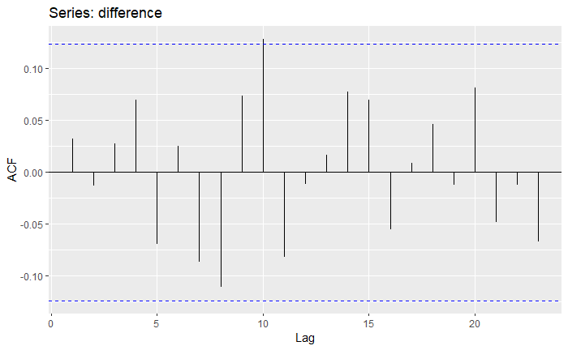

```r
ggAcf(difference)
```

PACF suggests how many AR terms to include

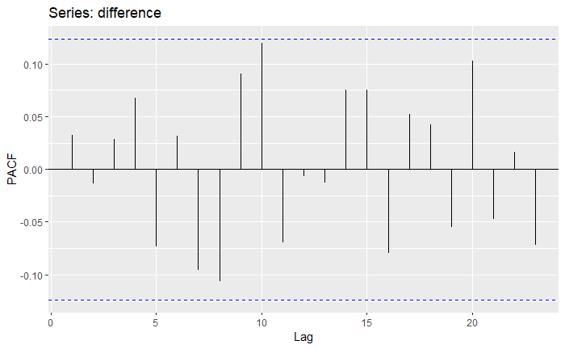

```r
# The **PACF** isolates direct lag-to-lag relationships and helps identify **AR (p)** components.

ggPacf(difference)
```

## ARIMA Model Fit

Fit an ARIMA model using the ACF/PACF guidance. order = c(0,1,10) means:

AR terms = 0

Differencing = 1 (already makes the series stationary)

MA terms = 10

```r
model <- Arima(Close, order = c(0,1,10))

summary(model)
```

```
Series: Close
ARIMA(0,1,10)

Coefficients:
         ma1     ma2     ma3     ma4      ma5     ma6      ma7      ma8     ma9    ma10
      0.0655  0.0220  0.0050  0.0768  -0.0738  0.0317  -0.0427  -0.1318  0.0812  0.1384
s.e.  0.0640  0.0646  0.0635  0.0647   0.0663  0.0610   0.0611   0.0641  0.0667  0.0606

sigma^2 = 27.92:  log likelihood = -769.14
AIC=1560.28   AICc=1561.38   BIC=1599.06

Training set error measures:
                    ME     RMSE      MAE       MPE     MAPE      MASE        ACF1
Training set 0.4392355 5.167567 3.545397 0.1194876 1.040274 0.9785514 -0.01948878
```

## Residual Diagnostics

After fitting the ARIMA model, it is essential to check whether the residuals behave like white noise

```
    Ljung-Box test

data:  Residuals from ARIMA(0,1,10)
Q* = 2.5919, df = 3, p-value = 0.4589

Model df: 10.   Total lags used: 13
```

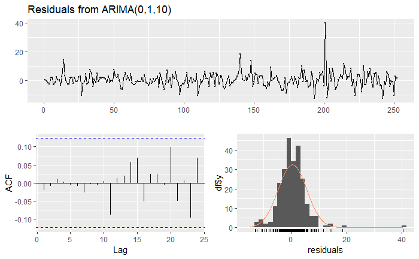

```r
checkresiduals(model)
```

## Forecasting

Generate a short-term forecast using the ARIMA model

```r
forecast(model) #yields 10 forecast values
```

|  | Point Forecast | Lo 80 | Hi 80 | Lo 95 | Hi 95 |
| --- | --- | --- | --- | --- | --- |
| 253 | 409.9001 | 403.1281 | 416.6720 | 399.5432 | 420.2569 |
| 254 | 408.9408 | 399.0452 | 418.8364 | 393.8068 | 424.0748 |
| 255 | 411.6666 | 399.3312 | 424.0019 | 392.8012 | 430.5319 |
| 256 | 411.5238 | 397.1398 | 425.9079 | 389.5254 | 433.5223 |
| 257 | 411.4452 | 395.0255 | 427.8648 | 386.3335 | 436.5569 |
| 258 | 412.6176 | 394.5997 | 430.6355 | 385.0616 | 440.1736 |
| 259 | 411.1307 | 391.5624 | 430.6990 | 381.2035 | 441.0578 |
| 260 | 409.6781 | 388.7769 | 430.5793 | 377.7124 | 441.6437 |
| 261 | 410.2325 | 388.3581 | 432.1068 | 376.7786 | 443.6864 |
| 262 | 410.4738 | 387.5062 | 433.4414 | 375.3478 | 445.5997 |

visualize the 10 forecast values

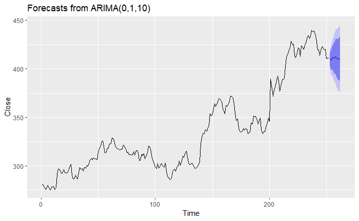

```r
autoplot(forecast(model))
```

## Auto ARIMA Comparison

Automatically selects the best ARIMA model (based on AICc) for comparison with the manually specified model above.

```r
auto.arima(Close)
```

```
Series: Close
ARIMA(0,1,0) with drift

Coefficients:
       drift
      0.5191
s.e.  0.3355

sigma^2 = 28.37:  log likelihood = -775.5
AIC=1554.99   AICc=1555.04   BIC=1562.04
```